# Rethinking: Chapter 4 EoC Questions

# Easy Questions

### 4E1 In the model definition below, which line is the likelihood?

$$y_i \sim Normal(\mu, \sigma) \\
\mu \sim Normal(0, 10) \\
\sigma \sim Exponential(1)$$

The first line is the likelihood.

### 4E2 In the model definition just above, how many parameters are in the posterior distribution?

2 parameters, $\mu$ and $\sigma$

### 4E4 In the model definition below, which line is the linear model?

$$\begin{align}
y_i &\sim Normal(\mu, \sigma) \\
\mu_i &= \alpha + \beta x_i \\
\alpha &\sim Normal(0, 10) \\
\beta &\sim Normal(0, 1) \\
\sigma &\sim Exponential(2)
\end{align}$$

the second line relating $\mu_i$ with $\alpha$ and $\beta$

### 4E5 In the model definition above, how many parameters are in the posterior distribution?

3, $\alpha$, $\beta$ , and $\sigma$

# Medium Questions

### 4M1 For the model definition below, simulate observed y values from the prior (not the posterior)

$$\begin{align}
y_i &\sim Normal(\mu, \sigma) \\
\mu &\sim Normal(0, 10) \\
\sigma &\sim Exponential(1)
\end{align}$$

```r
library(rethinking)
```

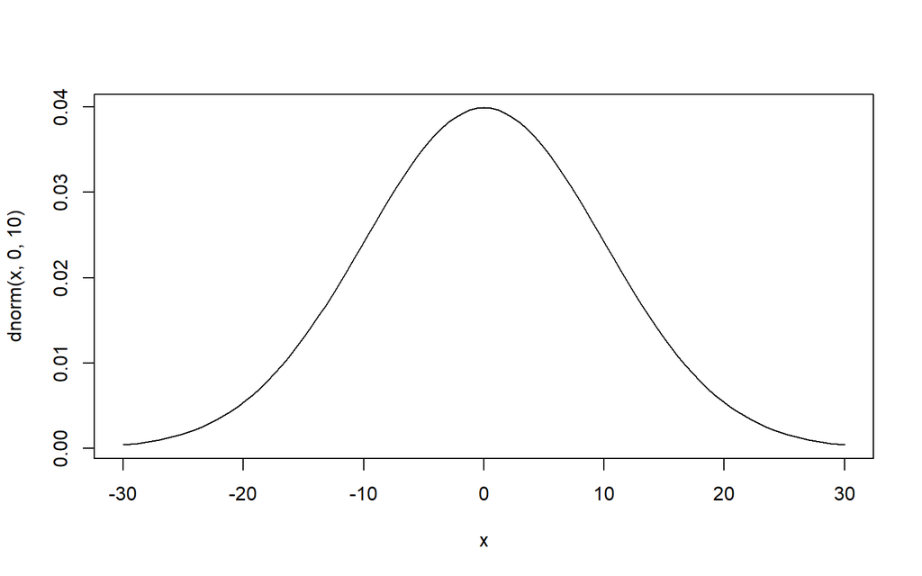

```r
# prior for mu
curve(dnorm(x, 0, 10), from = -30, to = 30)
```

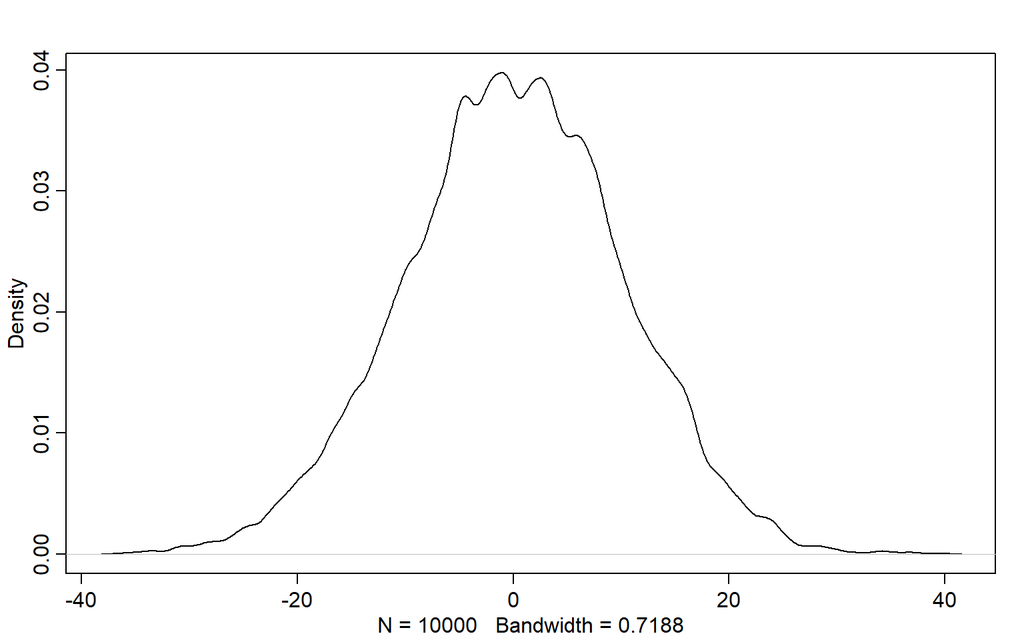

```r
# simulating y values from the prior
sample_mu <- rnorm(1e4, mean = 0, sd = 10)
sample_sigma <- rexp(1e4, 1)
sample_y <- rnorm(1e4, sample_mu, sample_sigma)
dens(sample_y)
```

### 4M2 Translate the model just above into a quap formula

```r
formula <- alist(
    y ~ dnorm(mu, sigma),
    mu ~ dnorm(0, 10),
    sigma ~ dexp(1)
)
```

### 4M3 Translate the quap model formula below into a mathematical model definition.

```r
alist(
    y ~ dnorm(mu, sigma),
    mu <- a + b*x,
    a ~ dnorm(0, 10),
    b ~ dunif(0, 1),
    sigma ~ dexp(1)
)
```

```
## [[1]]
## y ~ dnorm(mu, sigma)
##
## [[2]]
## mu <- a + b * x
##
## [[3]]
## a ~ dnorm(0, 10)
##
## [[4]]
## b ~ dunif(0, 1)
##
## [[5]]
## sigma ~ dexp(1)
```

$$\begin{align}
y &\sim Normal(\mu, \sigma) \\
\mu &= a + bx \\
a &\sim Normal(0, 10) \\
b &\sim Uniform(0, 1) \\
sigma &\sim Exponential(1)
\end{align}$$

### 4M4 A sample of students is measured for height each year for 3 years. After the third year, you want to fit a linear regression predicting height using year as a predictor. Write down the mathematical model definition for this regression, using any variable names and priors you choose. Be prepared to defend your choice of priors.

Students can be both boys and girls and ranging from the age let’s say 6 to 18. From this [source](https://childrenswi.org/medical-care/adolescent-health-and-medicine/issues-and-concerns/adolescent-growth-and-development/normal-growth), this means that the average height can range from 120cm to 190cm. Moreover, the yearly growth can range from 0 to 7 cm. [source2](https://www.verywellfamily.com/normal-growth-of-young-children-2632414). This growth rate cannot be negative.

The following model considers height is normally distributed and creates a linear relationship with the year the height was measured in. Thus the $\alpha$, the intercept term, captures the average height of all students, and $\beta$, the yearly growth rate. The $\sigma$ is assumed to be uniformly distributed with a very wide interval to capture all the age groups.

$$\begin{align}
height &\sim Normal(\mu, \sigma) \\
\mu &= \alpha + \beta \ t_i \\
\alpha &\sim Normal(155, 20) \\
\beta &\sim \operatorname{Log-Normal} (0,1) \\
\sigma &\sim Uniform(0, 50)
\end{align}$$

Checking the prior distributions and simulating the heights using them:

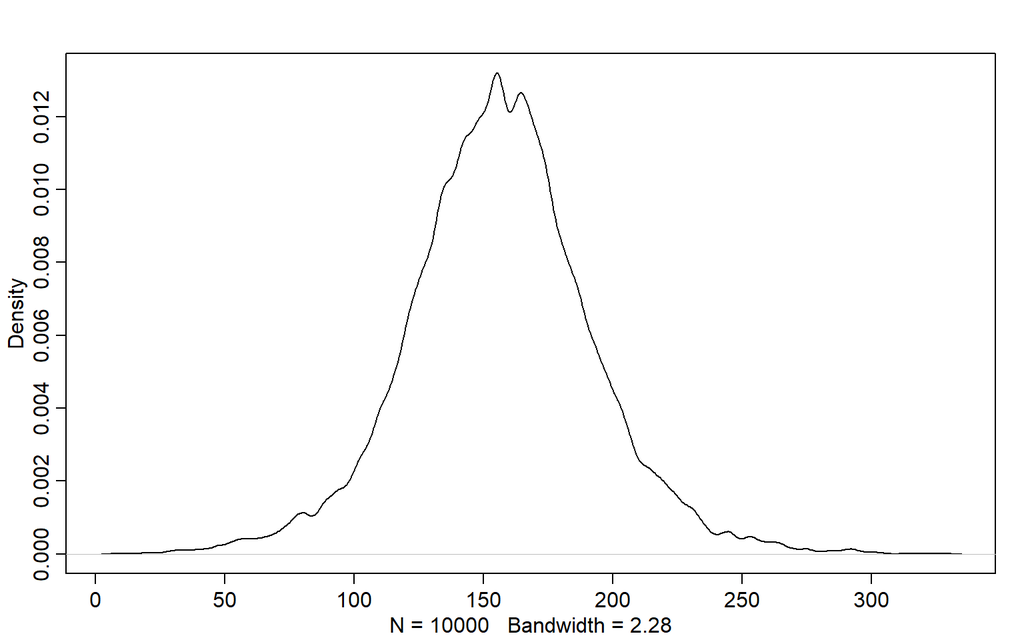

```r
samples_alpha = rnorm(1e4, 155, 20)
samples_beta = rlnorm(1e4, 0, 1)
samples_sigma = runif(1e4, 0, 50)

# for year 1, 2, 3
samples_mu1 = samples_alpha + samples_beta
samples_mu2 = samples_alpha + samples_beta * 2
samples_mu3 = samples_alpha + samples_beta * 3

# simulated heights for years 1, 2, 3
simulated_heights1 = rnorm(1e4, samples_mu1, samples_sigma)
simulated_heights2 = rnorm(1e4, samples_mu2, samples_sigma)
simulated_heights3 = rnorm(1e4, samples_mu3, samples_sigma)

# check simulated heights
dens(simulated_heights1)
```

```r
PI(simulated_heights1, 0.97)
```

```
##        2%       98%
##  74.46044 241.50898
```

```r
PI(simulated_heights2, 0.97)
```

```
##        2%       98%
##  78.18308 240.34141
```

```r
PI(simulated_heights3, 0.97)
```

```
##        2%       98%
##  76.10535 246.78405
```

### 4M5 Now suppose I remind you that every student got taller each year. Does this information lead you to change your choice of priors? How?

Since students got “taller”, we assume positive growth rates only, which we have already taken care of above using log-normal distribution for growth rates.

### 4M6 Now suppose I tell you that the variance among heights for students of the same age is never more than 64cm. How does this lead you to revise your priors?

Variance of 64 implies a sigma of 8. So we can update our prior for $\sigma$

$$\sigma \sim Uniform(0, 8)$$

### 4M7 Refit model m4.3 from the chapter, but omit the mean weight xbar this time. Compare the new model’s posterior to that of the original model. In particular, look at the covariance among the parameters. What is different? Then compare the posterior predictions of both models.

```r
data(Howell1);
d <- Howell1;
d2 <- d[ d$age >= 18 , ]

xbar <- mean(d2$weight)

m4.3 <- quap(
    alist(
        height ~ dnorm( mu , sigma ) ,
        mu <- a + b * ( weight - xbar) ,
        a ~ dnorm( 178 , 20 ) ,
        b ~ dlnorm( 0 , 1 ) ,
        sigma ~ dunif( 0 , 50 )
    ) ,
    data=d2
)


m4.3n <- quap(
    alist(
        height ~ dnorm( mu , sigma ) ,
        mu <- a + b * ( weight ) ,
        a ~ dnorm( 178 , 20 ) ,
        b ~ dlnorm( 0 , 1 ) ,
        sigma ~ dunif( 0 , 50 )
    ) ,
    data=d2
)

precis(m4.3)
```

```
##              mean         sd        5.5%       94.5%
## a     154.6006938 0.27032556 154.1686613 155.0327262
## b       0.9032263 0.04192643   0.8362198   0.9702328
## sigma   5.0722178 0.19118654   4.7666648   5.3777708
```

```r
precis(m4.3n)
```

```
##              mean         sd        5.5%       94.5%
## a     114.5395932 1.89776812 111.5065932 117.5725932
## b       0.8906174 0.04175844   0.8238794   0.9573555
## sigma   5.0727478 0.19125192   4.7670903   5.3784053
```

The $\alpha$ parameter has changed since weight is not centered anymore. Earlier, it was the average height when $x - \bar x$ was equal to 0, now it is the average height when the actual weight is zero.

```r
round(vcov(m4.3), 3)
```

```
##           a     b sigma
## a     0.073 0.000 0.000
## b     0.000 0.002 0.000
## sigma 0.000 0.000 0.037
```

```r
round(vcov(m4.3n), 3)
```

```
##            a      b sigma
## a      3.602 -0.078 0.009
## b     -0.078  0.002 0.000
## sigma  0.009  0.000 0.037
```

```r
round(cov2cor(vcov(m4.3)) , 3)
```

```
##           a      b  sigma
## a     1.000  0.000  0.001
## b     0.000  1.000 -0.003
## sigma 0.001 -0.003  1.000
```

```r
round(cov2cor(vcov(m4.3n)), 3)
```

```
##            a      b  sigma
## a      1.000 -0.990  0.026
## b     -0.990  1.000 -0.026
## sigma  0.026 -0.026  1.000
```

The covariance is much higher for the new model. If we look at the correlation, we see that the $\alpha$ and $\beta$ parameters are highly correlated together. The higher covariance can be explained since the weight parameter is not centered anymore and hence has more variation.

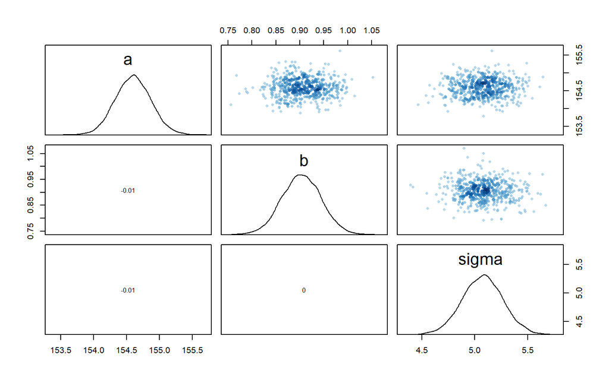

```r
pairs(m4.3)
```

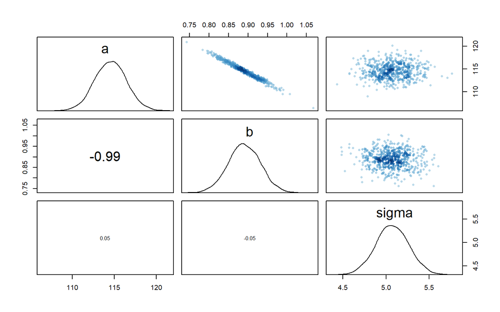

```r
pairs(m4.3n)
```

Comparing posterior predictions of the two models.

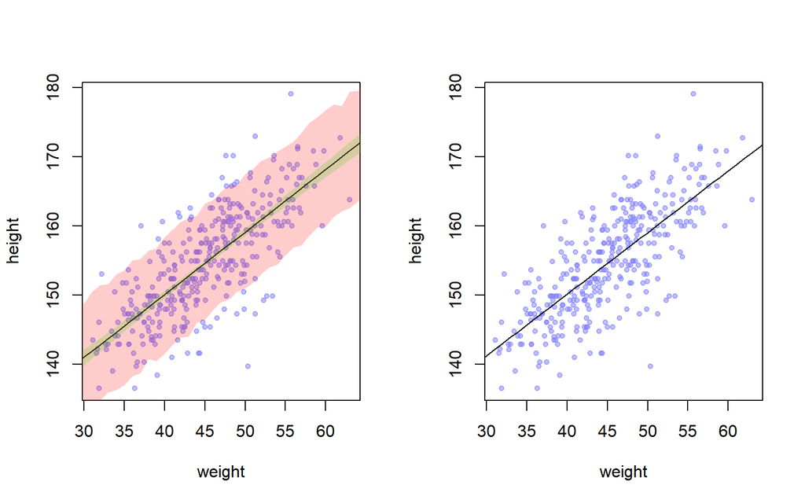

```r
weight.seq <- seq( from=25 , to=70 , by=1 )
dw <- data.frame(weight = weight.seq)

plot_wt_posterior <- function(model){
    mu <- link(model, dw)
    mu.mean <- apply(mu, 2, mean)
    mu.PI <- apply(mu, 2, PI)

    sim.h <- sim(model, dw)
    height.PI <- apply(sim.h, 2, PI)

    plot( height ~ weight , d2 , col=col.alpha(rangi2,0.5), pch = 20)
    lines( weight.seq , mu.mean )
    shade( mu.PI , weight.seq, col = col.alpha('green') )
    shade( height.PI , weight.seq , col = col.alpha('red'))
}

par(mfrow = c(1, 2))
plot_wt_posterior(m4.3)
plot_wt_posterior(m4.3n)
```

```r
par(mfrow = c(1,1))
```

The posterior predictions look to be the same. The figure on the left is the posterior prediction from the original model, while the one on the right is from the new model.

### 4M8 In the chapter, we used 15 knots with the cherry blossom spline. Increase the number of knots and observe what happens to the resulting spline. Then adjust also the width of the prior on the weights – change the standard deviation of the prior and watch what happens. What do you think the combination of knot number and the prior on the weights controls?

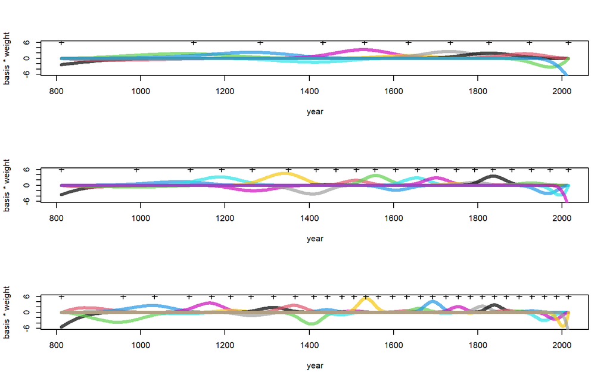

```r
data("cherry_blossoms")
d <- cherry_blossoms

d2 <- d[ complete.cases(d$doy) , ] # complete cases on doy

library(splines)
cherry_splines_model <- function(knots = 15){
    num_knots <- knots
    knot_list <- quantile( d2$year , probs=seq(0,1,length.out=num_knots) )

    B <- bs(d2$year,
            knots=knot_list[-c(1,num_knots)] ,
            degree=3 , intercept=TRUE )

    # create model

    m4.7 <- quap(
        alist( D ~ dnorm( mu , sigma ) ,
               mu <- a + B %*% w ,
               a ~ dnorm(100,10),
               w ~ dnorm(0, 10),
               sigma ~ dexp(1)
        ),
        data = list( D = d2$doy , B = B ) ,
        start = list( w = rep( 0 , ncol(B) ) ) )
    return(list(model = m4.7, knot_list = knot_list, B = B))
}

plot_basis_splines <- function(model, knot_list, B = B){
    # plotting posterior distribution
    post <- extract.samples( model )
    w <- apply( post$w , 2 , mean )

    # Plot the basis functions * weights calculated using quap
    plot( NULL , xlim=range(d2$year) , ylim=c(-6,6) ,
          xlab="year" , ylab="basis * weight" )
    for ( i in 1:ncol(B) )
        lines( d2$year , w[i]*B[,i] , col = col.alpha(i, 0.7), lwd = 4)
    points(knot_list, y = rep(6, length(knot_list)), pch = 3)
}

plot_posterior_predictions <- function(model, B = B, text = ncol(B)){
    # Posterior interval for mu (97%)
    mu <- link( model )
    mu_mean <- apply(mu, 2, mean)
    mu_PI <- apply(mu,2,PI,0.97)

    doy <- sim(model, list( D = d2$doy , B = B ))
    doy_h <- apply(doy, 2, PI, 0.97)

    plot( d2$year , d2$doy , col=col.alpha(rangi2,0.3) , pch=16 )
    lines(d2$year, mu_mean,  col = 'blue', lwd = 3)
    shade( mu_PI , d2$year , col=col.alpha("black",0.2) )
    shade(doy_h, d2$year, col = col.alpha('purple', 0.1))
    mtext(text)
}

model1 <- cherry_splines_model(knots = 10)
model2 <- cherry_splines_model(knots = 20)
model3 <- cherry_splines_model(knots = 30)  # gives warning that model did not converge

par(mfrow = c(3, 1))
plot_basis_splines(model1$model, model1$knot_list, B = model1$B)
plot_basis_splines(model2$model, model2$knot_list, B = model2$B)
plot_basis_splines(model3$model, model3$knot_list, B = model3$B)
```

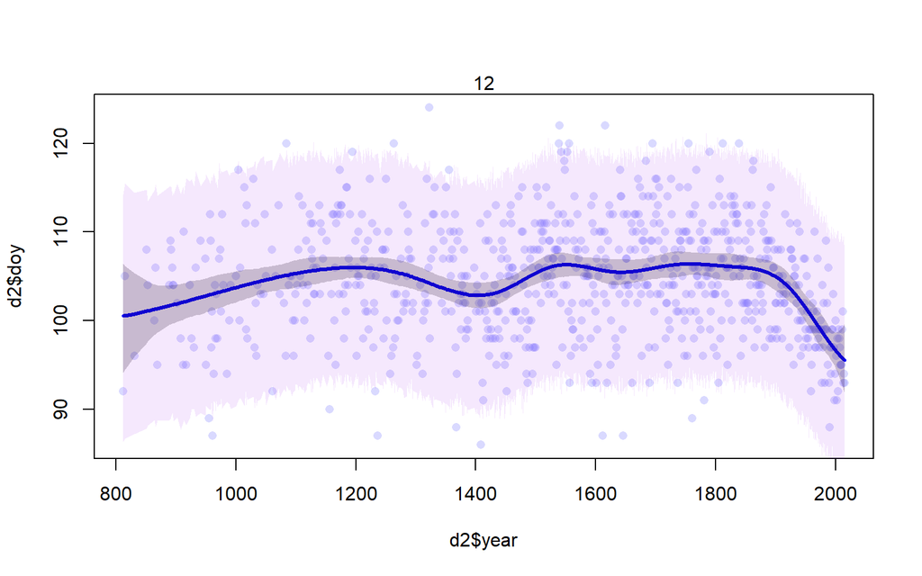

```r
plot_posterior_predictions(model1$model, model1$B)
```

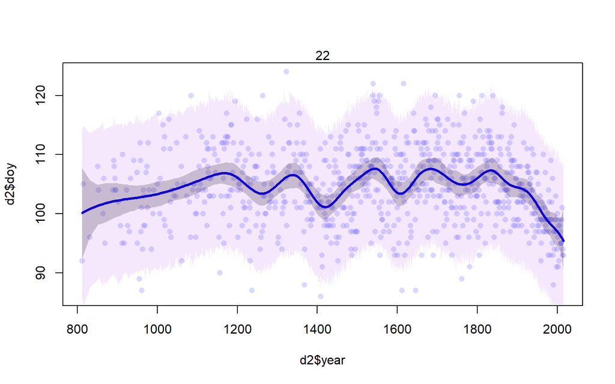

```r
plot_posterior_predictions(model2$model, model2$B)
```

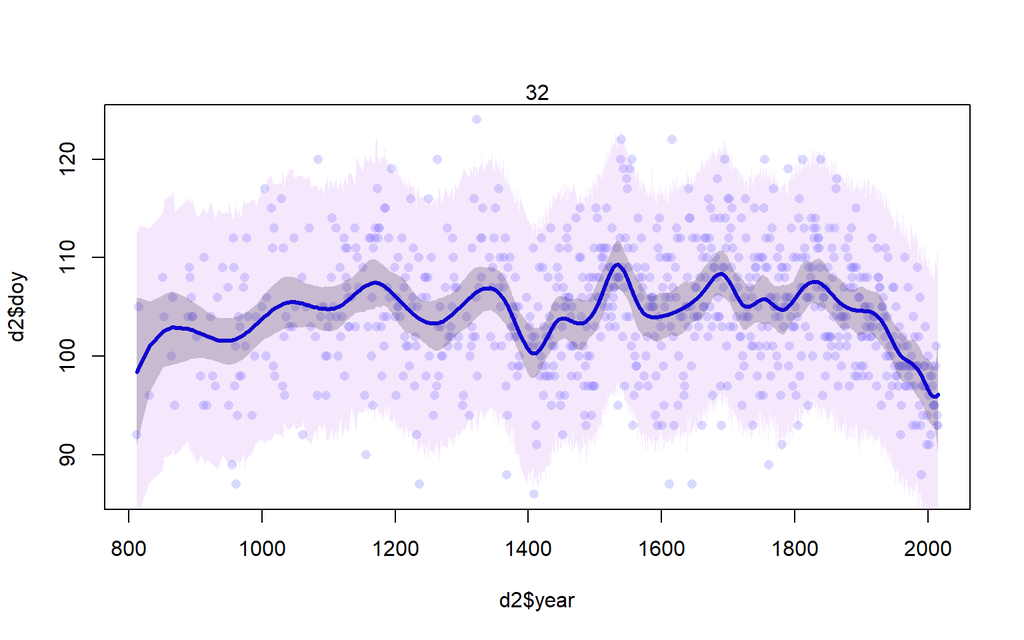

```r
plot_posterior_predictions(model3$model, model3$B)
```

The mean posterior prediction line becomes much more squiggly, especially in the middle years. With 10 knots the line is much more linear in the starting years and overall much more smooth. Increasing knots decreases the smoothness since now it can adjust to more local patterns.